# Kapittel 3: Bruk av Julia

## 3.1 Innledning

Vi starter med et lite avsnitt om hvorfor det kan være en god idé å bruke Julia, i stedet for alternativer som Matlab og Python. I likhet med Matlab er Julia laget for vitenskapelige beregninger, og har mye innebygget funksjonalitet for dette. Sammenlignet med Matlab er Julia mer moderne, det er gratis å bruke, det er i mange tilfeller [raskere](https://julialang.org/benchmarks/) enn Matlab, og det er mye enklere å bruke kode (pakker, funksjoner, etc.) som andre har laget, eller dele din egen kode så andre kan bruke den.

Mange av disse fordelene gjelder også i sammenligning med Python. Python er i motsetning til Julia ikke laget spesifikt for vitenskapelige beregninger, så Julia kan være mer “ergonomisk” når man skal gjøre vitenskapelige beregninger. Det kan også være vanskeligere å få relativt enkle programmer til å kjøre raskt, hvis man ikke er en erfaren Python-bruker.

I [dokumentasjonen](https://docs.julialang.org/en/v1/manual/noteworthy-differences/) til Julia kan du lese mer om forskjellene mellom Julia og andre språk (inkludert Python og Matlab).

Det finnes selvfølgelig flere grunner til å ikke bruke Julia, feks.

- Hvis man allerede har lang erfaring med Matlab eller Python, og ikke er interessert i å lære seg et nytt språk.
- Julia er ikke like utbredt som Matlab og Python, så det kan være pakker for spesielle bruksområder som ikke finnes i Julia. (Heldigvis kan man enkelt bruke Python-pakker i Julia, med pakken `PythonCall.jl`)

**NoteFor de spesielt interesserte**

Er du interessert i lære mer om Julia og forskjeller mellom Julia, Python, og Matlab? Her er noen kilder som kan være et godt utgangspunkt:

- [What’s bad about Julia?](https://viralinstruction.com/posts/badjulia/)
- [What’s great about Julia?](https://viralinstruction.com/posts/goodjulia/)
- [Why Numba and Cython are not substitutes for Julia](https://www.stochasticlifestyle.com/why-numba-and-cython-are-not-substitutes-for-julia/)
- [Matlab vs. Julia vs. Python](https://tobydriscoll.net/post/matlab-vs.-julia-vs.-python/)
- [Choosing a numerical programming language](https://cepr.org/voxeu/columns/choosing-numerical-programming-language-economic-research-julia-matlab-python-or-r)

Når det gjelder sammenligninger av [ytelse](https://julialang.org/benchmarks/), så er det ofte komplisert å sammenligne hvor raske ulike språk er. Spesielt å sammenligne Julia med optimalisert Python (f.eks. med Numpy, Numba og/eller Cython). I noen tilfeller er Julia raskere, i andre tilfeller kan Python være raskere. Du har kanskje hørt at man bør unngå for-løkker i Python og heller bruke f.eks. vektorisering med numpy? Det er fordi numpy er skrevet i C og er veldig raskt, men Python i seg selv er tregt. I Julia er situasjonen annerledes, der er språket i seg selv (inkludert for-løkker) raskt.

Den tredje blog-posten over viser at for et spesifikt reelt problem er Julia raskere enn optimalisert Python. Ytelse handler også mye om koden som skrives og hvor godt man utnytter de verktøyene som finnes i språket, og det fullt mulig å skrive et Julia-program med lav ytelse (se [“performance tips”](https://docs.julialang.org/en/v1/manual/performance-tips/) for tips for å unngå dette). Uansett hvilket språk man bruker så er det lurt å lære seg teknikker for høy ytelse, hvis dette er viktig for anvendelsen din.

Til syvende og sist faller språkvalget på personlige preferanser, og da er det i det minste en god idé å være klar over alternativene før man tar et valg. (Det er selvfølgelig ikke noe problem å lære seg flere språk!)

I dette dokumentet vil vi bruke standard Julia for beregninger, og plotte-biblioteket [Makie.jl](https://docs.makie.org/stable/) for plotting. `Makie.jl` er et moderne bibliotek for datavisualisering og plotting, og er et av de mest populære plotte-bibliotekene i Julia.

## 3.2 Litt grunnleggende Julia

#### 3.2.0 Installere Julia

Å installere Julia er enkelt. Det kan gjøres fra julialang.org/install/. Kort oppsummert: er du på en datamaskin med Linux eller macOS, er det bare å kjøre følgende kommando i terminalen:

```bash
curl -fsSL https://install.julialang.org | sh
```

Dette installerer også programmet `juliaup` som er et program for å håndtere ulike versjoner, og oppgradering av Julia. Hvordan man bruker `juliaup` er beskrevet på `juliaup` sin github-side: github.com/JuliaLang/juliaup

Hvis du bruker Windows kan du gå til [Microsoft store](https://apps.microsoft.com/detail/9njnww8pvkmn?hl=nb-NO&gl=NO), eller kjøre følgende kommando i kommandolinjen:

```
winget install --name Julia --id 9NJNWW8PVKMN -e -s msstore
```

Her vil vi gi en liten introduksjon til hvordan man starter med å bruke Julia. Det finnes mange andre ressurser på internett som kan hjelpe deg med å komme i gang, f.eks. [denne](https://youtube.com/playlist?list=PLhQ2JMBcfAsiu2BjeDuj0OXxD1Or_FjID&si=eNP1FW-ErIrD5fvA) spillelisten med korte videoer på YouTube.

Står du fast, vil som regel et kjapt Google-søk eller en LLM-prompt (f.eks. ChatGPT) hjelpe deg. Hvis dette ikke løser problemet, kan du spørre [forfatteren/oversetteren](https://www.mn.uio.no/math/personer/vit/kholme/) om hjelp.

### 3.2.1 Oppstart, grensesnitt, kommentarer

Vi ser at Julia starter med en liten hilsen, og en prompt `julia>`. Deretter kan vi skrive inn en kommando, trykke enter, og få svaret. For å avslutte Julia, skriver man `exit()` (eller trykker enter) eller gjør tastekombinasjonen `Ctrl+D`.

Programmet som kjører når vi bruker Julia i kommandolinjen kalles for Julias REPL. Det står for Read-Eval-Print Loop, og det er naturlig nok akkurat det en REPL gjør. Den leser kommandoer, evaluerer dem, og printer ut resultatet.

#### 3.2.1.1 Hjelpemodus

For å gå ut av hjelpemodusen trykker man tilbaketasten (backspace).

#### 3.2.1.2 Pakkemodus

**Note**

Avhengig av hvor mange andre pakker vi har i miljøet, kan det ta noen sekunder å installere pakker. Når vi installerer pakker blir koden til pakkene lasted ned og prekompilert.

Det kan være lurt å sette opp maskinen sin slik at [Revise.jl](https://timholy.github.io/Revise.jl/stable/) automatisk aktiveres når du starter Julia. Det kan du lese mer om her: [Revise.jl config](https://timholy.github.io/Revise.jl/stable/config/).

Når vi bruker Julia i forskjellige prosjekter, lønner det seg bruke spesifikke miljøer for hvert prosjekt. Hvis vi har en mappe som heter `MEK1100` der vi har all koden vi skriver for dette faget, lager vi et eget miljø for denne mappen ved å navigere til mappen i terminalen, starte Julia, gå inn i pakkemodusen og skrive `activate .` (punktumet skal være med!). Da endres prompten fra `(@v1.12) pkg>` til `(@MEK1100) pkg>`. Denne prompten betyr at vi er i miljøet for prosjektet `MEK1100`.

Nå er vi i miljøet for prosjektet `MEK1100`. Her kan vi legge til de pakkene vi trenger for dette emnet. I dette miljøet har vi også tilgang til alle pakkene vi har i grunnmiljøet. Når vi legger til pakker i et miljø, vil det bli opprettet en fil som heter `Project.toml` i mappen. Denne filen inneholder informasjon om pakkene vi har i miljøet, og versjonene av pakkene. Dette gjør det enkelt å bruke andres kode; du laster ned mappen med kode (inkludert `Project.toml`-filen), gjør pakke-kommandoen `activate .` og deretter `instantiate`. `instantiate`-kommandoen henter alle pakkene i `Project.toml`-filen og installerer de. Du kan da kjøre koden i mappen.

Å legge til disse pakkene kan ta litt tid, ettersom de har mye kode som skal prekompileres (jeg hadde allerede pakkene prekompilert når jeg tok dette opptaket).

##### 3.2.1.2.* Hvorfor Julia er raskere enn Matlab og Python

I motsetning til Matlab og Python, bruker Julia en såkalt “just-in-time”-kompilator, som kompilerer koden til maskinkode rett før den kjøres, i stedet for å kompilere koden til maskinkode når den installeres. Når dette gjøres spesialiseres funksjonene for de input-argumentene du bruker. Disse to tingene: spesialisering og kompilering, er det som gjør Julia raskere enn Matlab og Python, nesten like raskt som C. Ulempen med dette er det kan ta litt tid å kjøre en funksjon for første gang, fordi koden du skal kjøre må spesialiseres og kompileres. Men neste gang du kjører funksjonen vil den kjøre raskt, siden koden allerede er spesialisert og kompilert. Prekompilering er når Julia gjetter på hvordan du kommer til å bruke noen funksjoner i en pakke, og kompilerer koden til maskinkode på forhånd. Dette skjer som sagt ofte når vi laster ned pakker, eller oppdaterer pakker.

#### 3.2.1.3 Julia i VS Code

Det er vel og bra å kun bruke Julia i terminalen, men som oftest er det enklere å bruke Julia i et programmeringsgrensesnitt (engelsk: IDE - Integrated Development Environment). Det mest populære grensesnittet for Julia er VS Code, som er et gratis programmeringsgrensesnitt. Det kan lastes ned fra nettsiden [code.visualstudio.com](https://code.visualstudio.com/).

Når man har installert VS Code, er det neste man må gjøre å installere [utvidelsen for Julia](https://www.julia-vscode.org/docs/stable/gettingstarted/).

Når vi har Julia-utvidelsen, kan vi starte VS Code, åpne mappen vi skal lagre filene våre i (f.eks. MEK1100-mappen). Deretter kan vi starte med å lage et script. Da kan vi lage en mappe som heter `scripts`, og der opprette en fil som heter `script.jl`. Da kan vi skrive inn koden vår i filen.

Når vi har åpnet filen i VS Code, kan vi starte opp Julia i VS Code med å trykke `alt + j + o`. Da får vi opp en Julia-REPL, som er koblet til filene våre. Det betyr at vi kan skrive en linje i filen vår, trykke `ctrl + enter`. Så vil den linjen kjøres i vår REPL.

Her følger et opptak der vi demonstrerer hvordan vi kan bruke Julia i VS Code. Vi åpner MEK1100-mappen og starter Julia med `alt + j + o`. Vi åpner en fil som inneholder kode for å visualisere en funksjon. Deretter kjører vi filen linje for linje med `shift + enter` (dette gjør det samme som `ctrl + enter` i tillegg til å hoppe til neste linje). Resultatene av hver linje vises ved siden av linjen, og i vår REPL. Plottet vises i en ny fane i VS Code.

[video not shown]

julia_vs_code

#### 3.2.1.3 Numerikk

Numerikk i Julia gjøres med `Array`-er. I Julia er et `Array` en liste med elementer. Det kan være en liste med tall, en liste med strenger, en liste med funksjoner, osv. Vi kan også ha `Array`er i flere dimensjoner. Et én-dimensjonalt `Array` kalles ofte for en `Vector`, og et to-dimensjonalt `Array` kalles ofte for en `Matrix`. Vi kan lage en `Array` med klammeparenteser. Her skriver vi inn koden i filen vår, og trykker `ctrl + enter`. Da vil resultatet vises ved siden av linjen, og printes i REPL-en.

```julia
a = [1.2, 3.0, 4.2, 2.8]
```

```
4-element Vector{Float64}:
 1.2
 3.0
 4.2
 2.8
```

Her får vi at resultatet er en vector, som er det samme som en 1-dimensjonal array. Vi kan også lage en array med `zeros(n)`, `ones(n)`, `rand(n)`, `randn(n)`, etc. (Du kan jo bruke hjelpemodusen for å finne ut hva rand og randn gjør!). For eksempel:

```julia
zeros(3)
```

```
3-element Vector{Float64}:
 0.0
 0.0
 0.0
```

Vi kan også lage en 2-dimensjonal array med `zeros(m, n)`, `ones(m, n)`, `rand(m, n)`, `randn(m, n)`, etc. For eksempel:

```julia
b = rand(2,4)
```

```
2×4 Matrix{Float64}:
 0.944005  0.549083  0.590083   0.739405
 0.287821  0.479132  0.0673919  0.225881
```

For å prosessere data i arrays eller vectorer trenger vi funksjoner. I funksjoner kan vi lage funksjoner på flere måter. Har vi en kort funksjon kan vi skrive den slik:

```julia
f(x) = 3x + sin(2x)
```

```
f (generic function with 1 method)
```

Hvis funksjonen er mer komplisert kan vi skrive den slik:

```julia
function g(x)
    p = x + 1
    q = 2x - p
    return q^2
end
```

```
g (generic function with 1 method)
```

Vi kan bruke funksjonene slik:

```julia
a = 5.9
ga = g(a)
fa = f(a)
println("g(a) = $(round(ga,digits=2)), f(a) = $(round(fa,digits=2))")
```

```
g(a) = 24.01, f(a) = 17.01
```

Hvis vi vil anvende en funksjon på alle elementene i en array/vektor, kan vi bruke “broadcasting”. Det gjøres ved å skrive et punktum mellom funksjonsnavnet of argumentene:

```julia
w = [1.2, 3.0, 4.2, 2.8]
g.(w)
```

```
4-element Vector{Float64}:
  0.0399999999999999
  4.0
 10.240000000000002
  3.2399999999999993
```

Dette fungerer også for funksjoner som har flere variabler. For eksempel:

```julia
h(x, y) = x + 1000y
u = [1.2, 3.0, 4.2, 2.8]
w = [9.8, 4.1, 5.7, 8.7]
h.(u, w)
```

```
4-element Vector{Float64}:
 9801.2
 4103.0
 5704.2
 8702.8
```

Her anvender vi funksjonen `h` parvis på elementene i vektorene `u` og `w`. Hvis vi vil anvende funksjonen på alle kombinasjoner av elementer i vektorene `u` og `w`, kan vi transponere den ene vektoren, så den blir en radvektor:

```julia
w'
```

```
1×4 adjoint(::Vector{Float64}) with eltype Float64:
 9.8  4.1  5.7  8.7
```

Her ser vi at `w'` er en radvektor. Apostrof er tegnet for transponering i Julia. Vi kan så anvende funksjonen `h` på alle kombinasjoner av elementer i vektorene `u` og `w`:

```julia
M = h.(u, w')
```

```
4×4 Matrix{Float64}:
 9801.2  4101.2  5701.2  8701.2
 9803.0  4103.0  5703.0  8703.0
 9804.2  4104.2  5704.2  8704.2
 9802.8  4102.8  5702.8  8702.8
```

Her ser vi at et element $M_{i,j}$ er $h(u[i], w[j])$ for $i = 1:4$ og $j = 1:4$.

#### 3.2.1.4 Plotting

Nå skal vi se kjapt på hvordan vi kan plotte data med `Makie.jl`. Her importerer vi først `CairoMakie.jl`, lager noen punkter, og plotter dem.

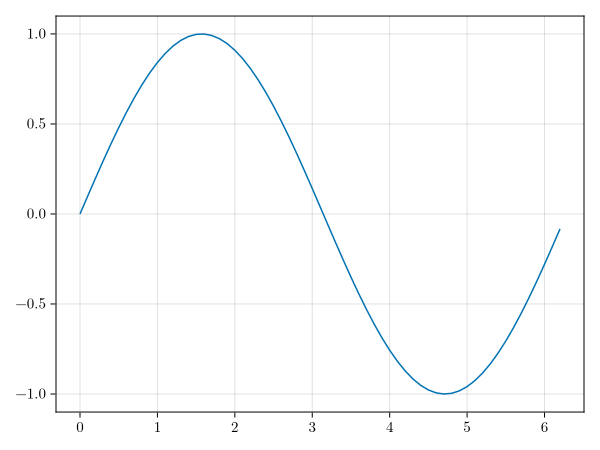

```julia
using CairoMakie
x = 0:0.1:2π
y = sin.(x)
lines(x, y)
```

Her brukte vi funksjonen `lines` som plottet linjen mellom punktene i vektorene `x` og `y`. Ofte vil vi ha litt mer kontroll over figurene vi lager, og da kan vi bruke funksjonen `Figure` og `Axis`, for å først lage en figur, så plassere en akse i figuren, og så plotte forskjellige ting i aksen:

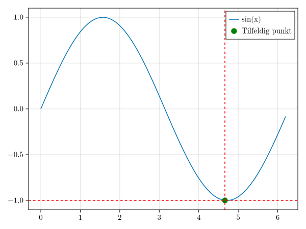

```julia
t = 0:0.1:2π
y = sin.(t)
random_point_t = rand() .* 2π
random_point_y = sin(random_point_t)

fig = Figure()
ax = Axis(fig[1, 1])
lines!(ax, x, y, label="sin(x)")
scatter!(ax, random_point_t, random_point_y, label="Tilfeldig punkt", markersize=16, color= :green)
vlines!(ax, random_point_t, color=:red, linestyle=:dash)
hlines!(ax, random_point_y, color=:red, linestyle=:dash)
axislegend(ax)
fig
```

Her har vi brukt flere forskjellige plottefunksjoner fra `Makie.jl`. Bruk hjelpemodusen for å finne ut hva de gjør! Vi legger merke til at `lines!`-funksjonen vi brukte her sluttet med et utropstegn. Dette er en konvensjon som indikerer at funksjonen endrer på noen av argumentene. Her endrer vi på aksen, ved å plotte en linje. Ellers er `lines!`-funksjonen og `lines`-funksjonen like. Vi kan også se at vi bruker `axislegend`-funksjonen til å legge til en beskrivelse av de forskjellige plottene.

Hvis vi vil lagre figuren vår til en fil, kan vi bruke funksjonen `save`. For eksempel:

```julia
filnavn = joinpath("figurer", "sin_plot.png")
mkpath("figurer")
save(filnavn, fig)
```

Her har vi brukt funksjonen `joinpath` til å lage en filsti til en mappe som heter `figurer`, og en fil som heter `sin_plot.png`. Vi har også brukt funksjonen `mkpath` til å lage mappen hvis den ikke finnes.

#### 3.2.1.5 Emojier og symboler

For å få $\LaTeX$-symboler, kan vi bruke `\` før symbolet, slik som `\pi` for $\pi$, deretter trykker vi`tab` for å gjøre om `\pi` til $\pi$. For emojier bruker vi en kolon før symbolet, slik som `\:smile:` for 😄, og trykker `tab` for å gjøre om `\:smile:` til 😄. Er du usikker på hva en emoji heter, kan du trykke `tab` før du har skrevet ferdig navnet, f.eks. `\:smil` + `tab` for å få opp alle emojiene der navnet begynner på `smil`.

I tillegg til de vanlige variabeltypene (string, skalar, vektor, osv…) har Julia også en type som heter `Symbol`. Et `Symbol` er litt som en string, og er mye brukt i Julia. Man lager et `Symbol` ved å bruke `:` før teksten. For eksempel:

```julia
a = :hei
typeof(a)
```

```
Symbol
```

Her er `a` av typen `Symbol`.